# Análisis Bayesiano utilizando Rstan - Accidentes de tránsito en Finlandia

Cristhian Ortiz

Trabajo Final de Curso

# Inicialización

**Paquetes Requeridos**

```r
library(ggplot2)
library(tidyr)
library(gridExtra)
library(rstanarm)
library(rstan)
library(bayesplot)

theme_set(theme_minimal()) #ggplot theme
rstan_options(auto_write = TRUE)
options(mc.cores = parallel::detectCores())

setwd("C:/Users/Cristhian/Desktop/Rstan")
```

# 1 Introducción

El presente Código muestra un análisis de series de tiempo del número de muertes ocurridas por accidentes de tránsito al año en Finlandia.

# 2 Data

Importamos el registro de muertes por accidente de tránsito en Finlandia desde el año 1993 al 2016

```r
deaths <- read.csv("./trafficdeaths.csv")
head(deaths)
```

```
##   year deaths
## 1 1993    434
## 2 1994    423
## 3 1995    411
## 4 1996    355
## 5 1997    391
## 6 1998    367
```

Realizando un gráfico para observar la distribución de los datos

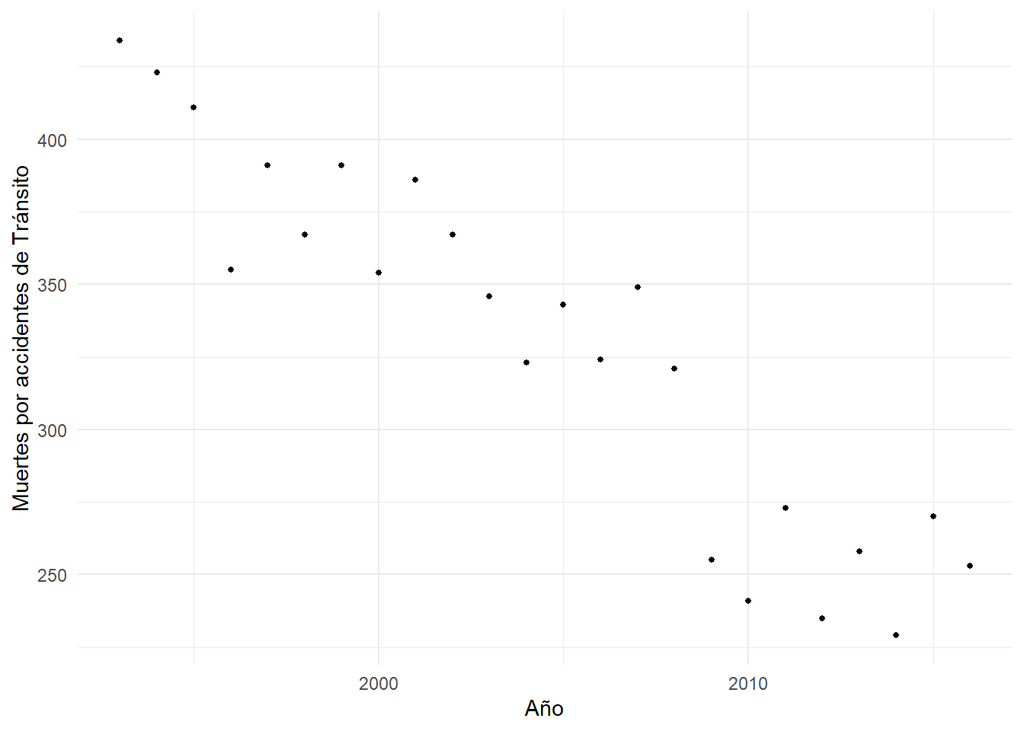

```r
ggplot() +
    geom_point(aes(year, deaths), data = deaths, size = 1) +
    labs(y = 'Muertes por accidentes de Tránsito', x= "Año") +
    guides(linetype = F)
```

# 3 Modelo de regresión de Poisson

El número de muertes son count data (datos en el que las observaciones solo son valores enteros no negativos), por lo que usamos el modelo Poisson. Primero Fijamos el modelo log-lineal para la intensidad de Poisson, que corresponde a suponer un cambio proporcional constante.

```r
fit_lin <- stan_glm(deaths ~ year, data=deaths, family="poisson",
                    refresh=100, iter=1000, chains=4, seed=1234, refresh=0)
```

Veamos la distribución predictiva posterior (mediana e intervalos de 5% y 95%).

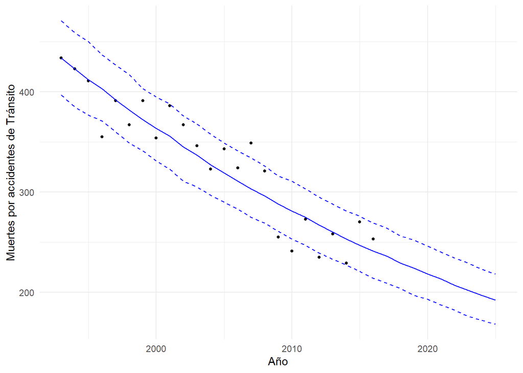

```r
x_predict <- seq(1993,2025)
N_predict <- length(x_predict)
y_predict <- posterior_predict(fit_lin, newdata=data.frame(year=x_predict))
mu <- apply(t(y_predict), 1, quantile, c(0.05, 0.5, 0.95)) %>%
    t() %>% data.frame(x = x_predict, .) %>% gather(pct, y, -x)
pfit <- ggplot() +
    geom_point(aes(year, deaths), data = deaths, size = 1) +
    geom_line(aes(x, y, linetype = pct), data = mu, color = 'blue') +
    scale_linetype_manual(values = c(2,1,2)) +
    labs(x = 'Año', y = 'Muertes por accidentes de Tránsito') +
    guides(linetype = F)
(pfit)
```

A continuación, ajustamos un modelo “spline no lineal” con stan_gamm4 (permite que los predictores designados tengan un efecto no lineal)

```r
fit_gam <- stan_gamm4(deaths ~ year + s(year), data=deaths,
                      family="poisson", adapt_delta=0.999,
                      refresh=100, iter=1000, chain=4, seed=1234, refresh=0)
monitor(fit_gam$stanfit)
```

```
## Inference for the input samples (4 chains: each with iter = 1000; warmup = 0):
##
##                         Q5    Q50    Q95   Mean   SD  Rhat Bulk_ESS Tail_ESS
## (Intercept)          -71.0   41.7  145.3   41.2 73.1     1      526      520
## year                  -0.1    0.0    0.0    0.0  0.0     1      526      520
## s(year).1             -0.7    0.1    1.1    0.1  0.6     1     1444     1259
## s(year).2             -1.6   -0.4    0.2   -0.5  0.6     1     1005     1266
## s(year).3             -1.0   -0.1    0.6   -0.2  0.5     1     1383     1444
## s(year).4             -0.5    0.0    0.7    0.1  0.4     1     1653     1543
## s(year).5             -0.8   -0.1    0.4   -0.2  0.3     1     1546     1421
## s(year).6              0.1    0.5    0.9    0.5  0.2     1      707      678
## s(year).7             -0.1    0.2    0.5    0.2  0.2     1     1139     1755
## s(year).8             -0.9   -0.3    0.1   -0.4  0.3     1      855     1387
## s(year).9             -2.0    0.0    2.0    0.1  1.3     1      588      574
## smooth_sd[s(year)1]    0.1    0.5    1.1    0.5  0.3     1      417      605
## smooth_sd[s(year)2]    0.1    0.7    2.8    1.0  0.9     1      828      792
## mean_PPD             319.9  329.2  338.3  329.2  5.4     1     2238     1711
## log-posterior       -134.5 -127.9 -123.5 -128.3  3.4     1      407      806
##
## For each parameter, Bulk_ESS and Tail_ESS are crude measures of
## effective sample size for bulk and tail quantities respectively (an ESS > 100
## per chain is considered good), and Rhat is the potential scale reduction
## factor on rank normalized split chains (at convergence, Rhat <= 1.05).
```

Construyendo la distribución predictiva posterior.

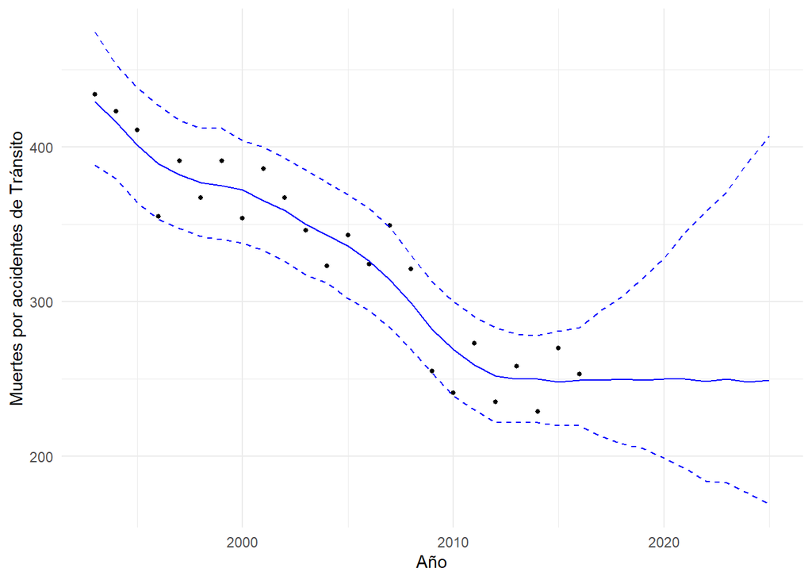

```r
x_predict=seq(1993,2025)
N_predict=length(x_predict)
y_predict <- posterior_predict(fit_gam, newdata=data.frame(year=x_predict))
mu <- apply(t(y_predict), 1, quantile, c(0.05, 0.5, 0.95)) %>%
    t() %>% data.frame(x = x_predict, .) %>% gather(pct, y, -x)
pfit <- ggplot() +
    geom_point(aes(year, deaths), data = deaths, size = 1) +
    geom_line(aes(x, y, linetype = pct), data = mu, color = 'blue') +
    scale_linetype_manual(values = c(2,1,2)) +
    labs(x = 'Año', y = 'Muertes por accidentes de Tránsito') +
    guides(linetype = F)

(pfit)
```

La mediana predictiva es claramente no lineal. La media de predicción para los años futuros se mantiene al mismo nivel que las observaciones más recientes, pero la incertidumbre aumenta rápidamente. Finalmente ajustamos el proceso gaussiano centrado en el modelo lineal usando el lenguaje Stan:

```r
N<-nrow(deaths)
Ey<-mean(deaths$deaths)
d_data <- list(N=N, x=deaths$year, y=deaths$deaths, Ey=Ey, N_predict=N_predict,
               x_predict=x_predict, alpha0=2, beta0=4)
fit_gp <- stan("./poisson_gp.stan", data=d_data, refresh=100, iter=1000,
               chains=4, seed=1234, init=0, control=list(adapt_delta=0.999))
monitor(fit_gp)
```

```
## Inference for the input samples (4 chains: each with iter = 1000; warmup = 0):
##
##                     Q5     Q50     Q95    Mean   SD  Rhat Bulk_ESS Tail_ESS
## lscale             0.9     2.2     5.6     2.6  1.7  1.01      299      524
## alpha              0.0     0.1     0.2     0.1  0.1  1.00      656      560
## a                 -0.1     0.0     0.1     0.0  0.0  1.00     1257     1033
## b                  0.0     0.0     0.0     0.0  0.0  1.00     1425     1062
## z[1]              -1.4     0.0     1.3     0.0  0.8  1.00     1774     1519
## z[2]              -1.6    -0.3     0.9    -0.4  0.8  1.00     1838     1558
## z[3]              -1.8    -0.4     1.1    -0.4  0.9  1.00     1445     1576
## z[4]              -1.5    -0.1     1.4    -0.1  0.9  1.00      995     1628
## z[5]              -1.3     0.2     1.7     0.2  0.9  1.00     2473     1489
## z[6]              -1.3     0.1     1.6     0.2  0.9  1.00     2206     1403
## z[7]              -1.3     0.3     1.7     0.3  0.9  1.00     2141     1137
## z[8]              -1.3     0.2     1.6     0.2  0.9  1.00     2450     1642
## z[9]              -1.3     0.2     1.8     0.2  0.9  1.00     2193     1628
## z[10]             -1.4     0.1     1.5     0.1  0.9  1.00     2251     1129
## z[11]             -1.4     0.1     1.7     0.1  0.9  1.00     2142     1419
## z[12]             -1.3     0.3     1.9     0.3  1.0  1.00     1733     1377
## z[13]             -1.3     0.3     1.9     0.3  1.0  1.01      885     1340
## z[14]             -1.7     0.1     1.7     0.0  1.0  1.00      959     1496
## z[15]             -2.0    -0.3     1.6    -0.3  1.1  1.00      773     1042
## z[16]             -2.3    -0.7     0.9    -0.7  1.0  1.00     1683     1728
## z[17]             -2.3    -0.6     1.0    -0.6  1.0  1.00      875     1490
## z[18]             -1.7    -0.2     1.4    -0.2  1.0  1.00     1799     1545
## z[19]             -1.7    -0.1     1.5    -0.1  0.9  1.00     1539     1452
## z[20]             -1.7    -0.2     1.5    -0.2  0.9  1.00     1296     1336
## z[21]             -1.3     0.1     1.7     0.2  0.9  1.00     1827     1506
## z[22]             -1.3     0.2     1.8     0.2  1.0  1.01     2420     1524
## z[23]             -1.4     0.3     1.8     0.3  1.0  1.00     2396     1535
## z[24]             -1.6     0.1     1.7     0.1  1.0  1.00     2787     1517
## mu_predict[1]    409.7   433.5   460.5   434.0 15.7  1.00     2508     1501
## mu_predict[2]    398.8   418.8   440.0   419.0 12.5  1.00     1885     1761
## mu_predict[3]    383.9   401.3   419.1   401.7 11.3  1.00     2115     1822
## mu_predict[4]    367.4   387.0   405.0   386.7 11.6  1.00     1404     1659
## mu_predict[5]    361.1   380.3   399.2   380.4 11.6  1.00     1999     1832
## mu_predict[6]    359.2   377.0   395.5   377.1 10.9  1.00     2540     1913
## mu_predict[7]    358.0   374.3   392.6   374.8 10.6  1.00     2229     1583
## mu_predict[8]    353.9   370.7   389.4   371.0 10.8  1.00     2253     1728
## mu_predict[9]    350.6   367.1   385.8   367.4 10.8  1.00     2021     1627
```

[output cut: 72 more lines]

```
## log_lik[16]       -5.7    -4.4    -3.8    -4.5  0.6  1.00     1059     1717
## log_lik[17]       -6.3    -4.9    -3.8    -4.9  0.8  1.00     1293     1532
## log_lik[18]       -6.6    -4.8    -3.8    -4.9  0.9  1.00      997     1421
## log_lik[19]       -5.6    -4.2    -3.7    -4.4  0.7  1.00     1295     1552
## log_lik[20]       -5.7    -4.3    -3.7    -4.4  0.7  1.00     1563     1673
## log_lik[21]       -4.6    -3.8    -3.7    -4.0  0.4  1.00     1811     1780
## log_lik[22]       -6.0    -4.5    -3.8    -4.7  0.7  1.00     2220     1703
## log_lik[23]       -5.9    -4.4    -3.7    -4.6  0.7  1.00     1683     1953
## log_lik[24]       -4.7    -3.8    -3.7    -4.0  0.4  1.00     1823     1677
## lp__           37989.1 37997.9 38004.2 37997.4  4.6  1.00      547     1011
##
## For each parameter, Bulk_ESS and Tail_ESS are crude measures of
## effective sample size for bulk and tail quantities respectively (an ESS > 100
## per chain is considered good), and Rhat is the potential scale reduction
## factor on rank normalized split chains (at convergence, Rhat <= 1.05).
```

Calculemos la distribución predictiva posterior.

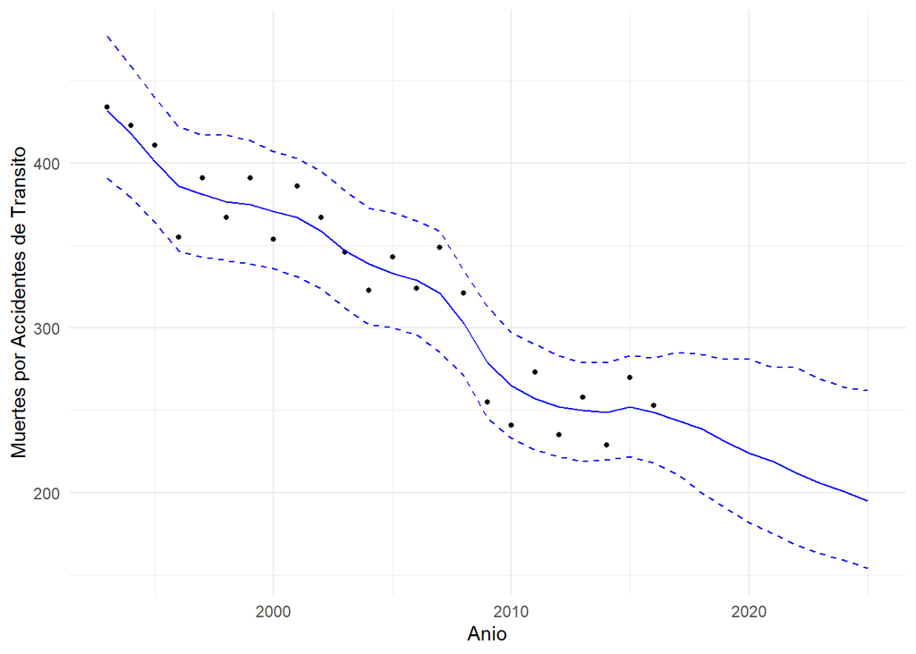

```r
gp_params <- extract(fit_gp)
mu <- apply(t(gp_params$y_predict), 1, quantile, c(0.05, 0.5, 0.95)) %>%
    t() %>% data.frame(x = x_predict, .) %>% gather(pct, y, -x)
pfit <- ggplot() +
    geom_point(aes(year, deaths), data = deaths, size = 1) +
    geom_line(aes(x, y, linetype = pct), data = mu, color = 'blue') +
    scale_linetype_manual(values = c(2,1,2)) +
    labs(x = 'Anio', y = 'Muertes por Accidentes de Transito') +
    guides(linetype = F)
(pfit)
```